# weightedsurv vignettes: every figure before (ac76f82) and after (HEAD) the vignette revision

Figures are paired by order of appearance in the knitted file and labelled by file and chunk. Both sets were knitted with `knitr::knit` (png, 96 dpi) against the same build of the package (`R/` is identical at the two commits).

| File | Figures | Pairs with byte-identical image files |
| --- | --- | --- |
| `vignettes/weightedsurv_examples.Rmd` | 18 figure pair(s) | 8 of 18 |
| `vignettes/articles/martingale_resampling_applications.Rmd` | 6 figure pair(s) | 1 of 6 |
| `vignettes/articles/weightedcox_methodology.Rmd` | 1 figure pair(s) | 1 of 1 |
| `vignettes/articles/weightedkm_methodology.Rmd` | no figures (no evaluated chunk draws one) | – |
| `vignettes/articles/weightedrmst_methodology.Rmd` | no figures (no evaluated chunk draws one) | – |
| `vignettes/articles/weightedcox_wald-vs-logrank_simulations.Rmd` | 3 figure pair(s) | 3 of 3 |

## vignettes/weightedsurv_examples.Rmd

### 1. Flowchart of the weighting schemes (wt.rg.S)

vignettes/weightedsurv_examples.Rmd · chunk before: `unnamed-chunk-1 (figure 1)` · chunk after: `unnamed-chunk-1 (figure 1)` · image files byte-identical

Before (ac76f82)

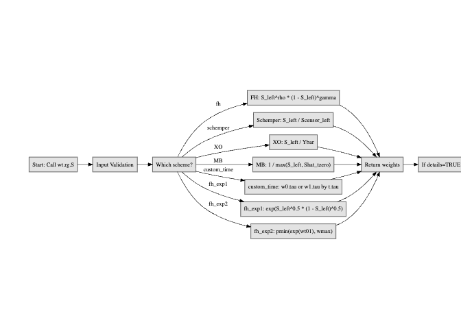

After (HEAD)

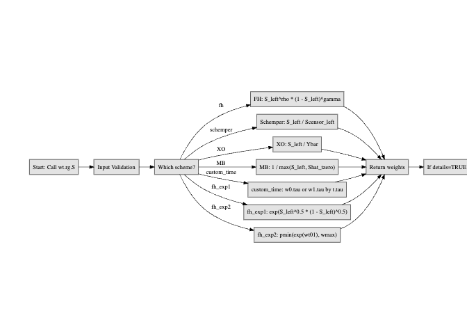

Before (ac76f82)

After (HEAD)

### 3. GBSG K-M curves, plot_weighted_km and survfit

vignettes/weightedsurv_examples.Rmd · chunk before: `unnamed-chunk-7 (figure 1)` · chunk after: `unnamed-chunk-7 (figure 1)` · image files byte-identical

Before (ac76f82)

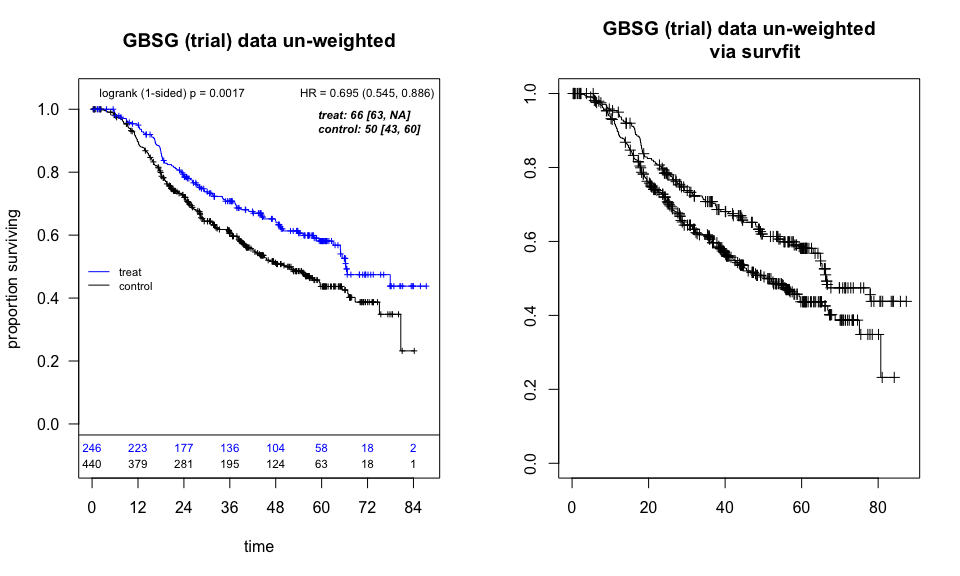

After (HEAD)

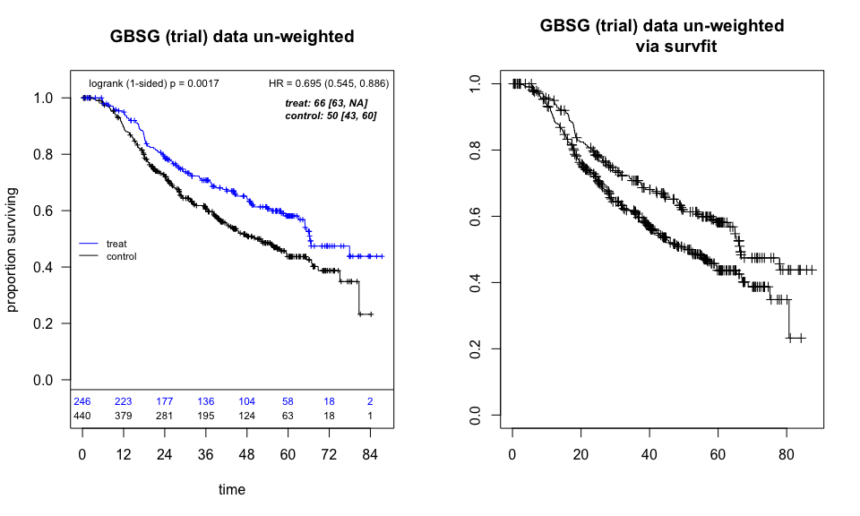

### 4. GBSG K-M curves with 95% CIs

vignettes/weightedsurv_examples.Rmd · chunk before: `unnamed-chunk-8 (figure 1)` · chunk after: `unnamed-chunk-8 (figure 1)` · image files byte-identical

Before (ac76f82)

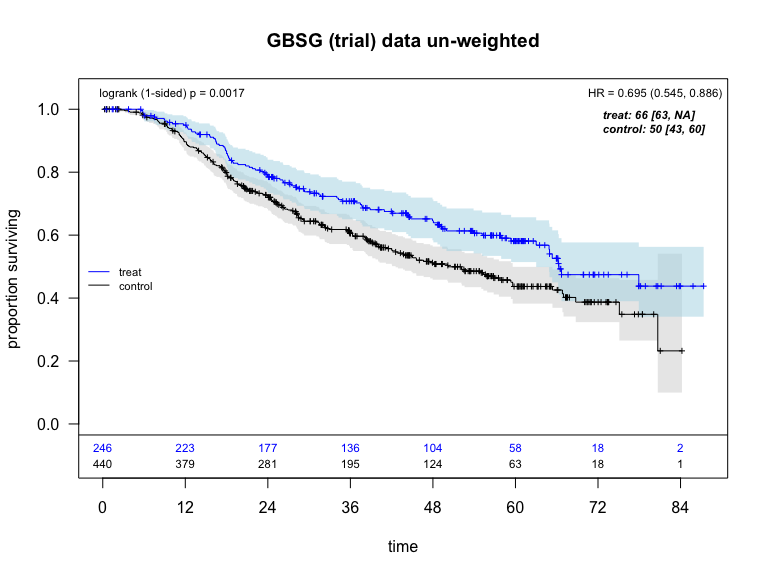

After (HEAD)

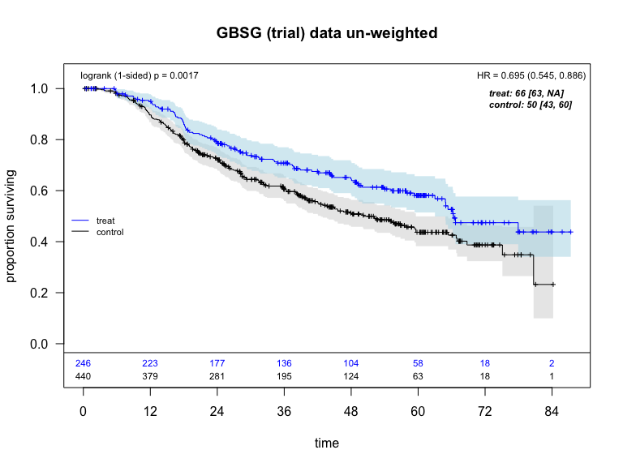

### 5. Rotterdam K-M curves, un-weighted and weighted

vignettes/weightedsurv_examples.Rmd · chunk before: `unnamed-chunk-15 (figure 1)` · chunk after: `unnamed-chunk-16 (figure 1)` · image files differ

Before (ac76f82)

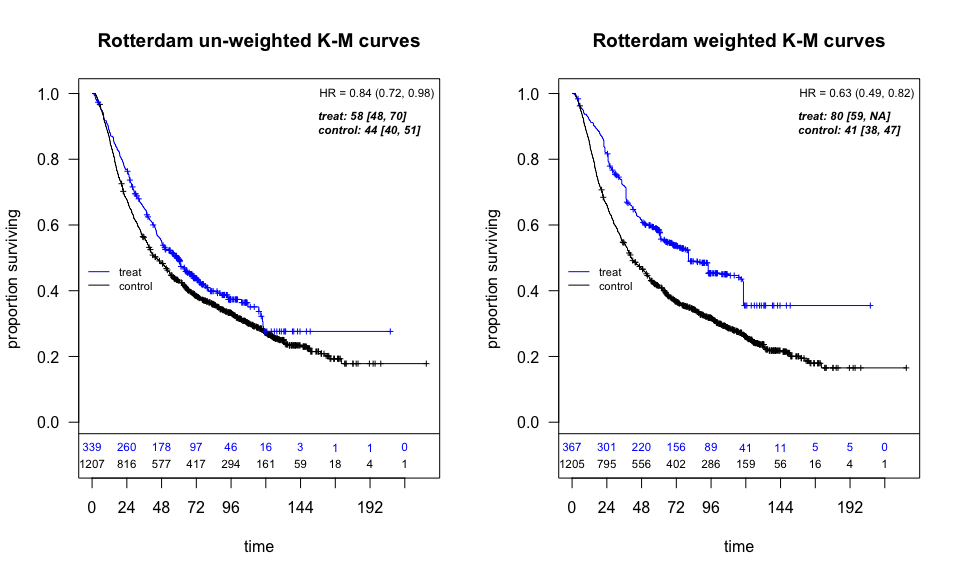

After (HEAD)

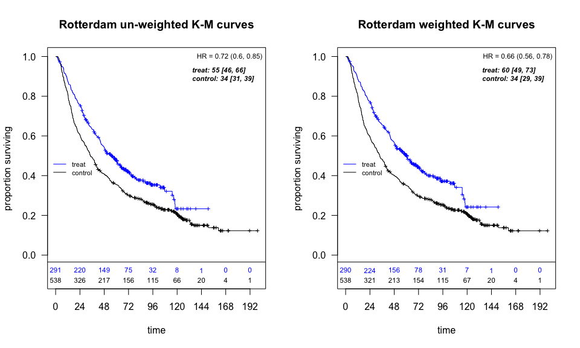

### 6. GBSG and Rotterdam weighted K-M curves

vignettes/weightedsurv_examples.Rmd · chunk before: `unnamed-chunk-16 (figure 1)` · chunk after: `unnamed-chunk-17 (figure 1)` · image files differ

Before (ac76f82)

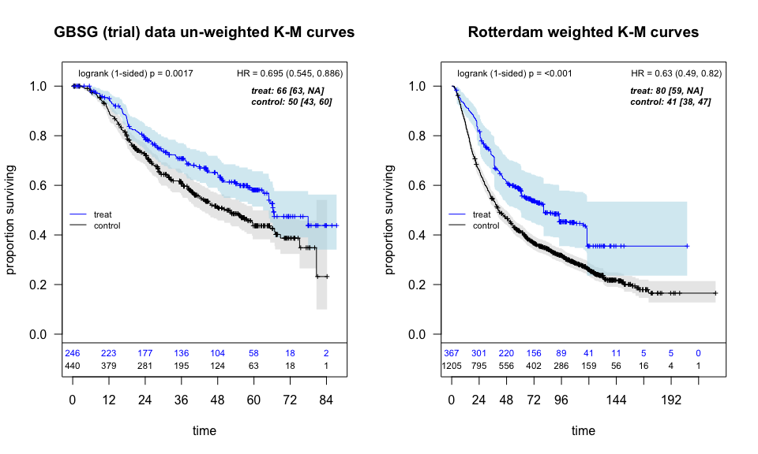

After (HEAD)

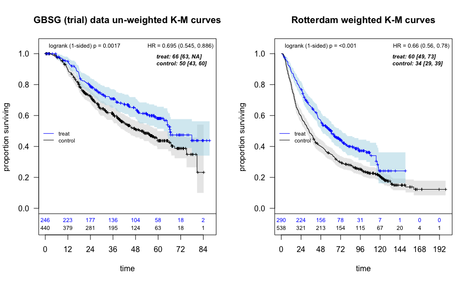

### 7. Rotterdam weighted survival difference: resampled curves and band

vignettes/weightedsurv_examples.Rmd · chunk before: `unnamed-chunk-17 (figure 1)` · chunk after: `rotterdam-band-resamples (figure 1)` · image files differ

Before (ac76f82)

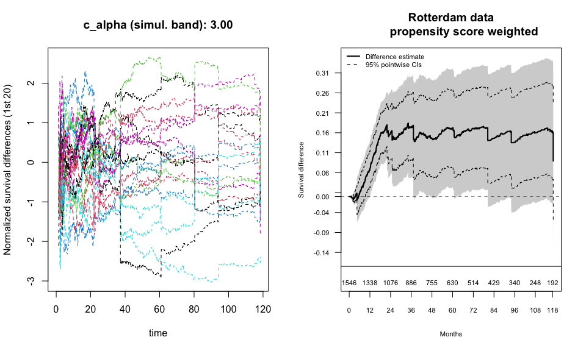

After (HEAD)

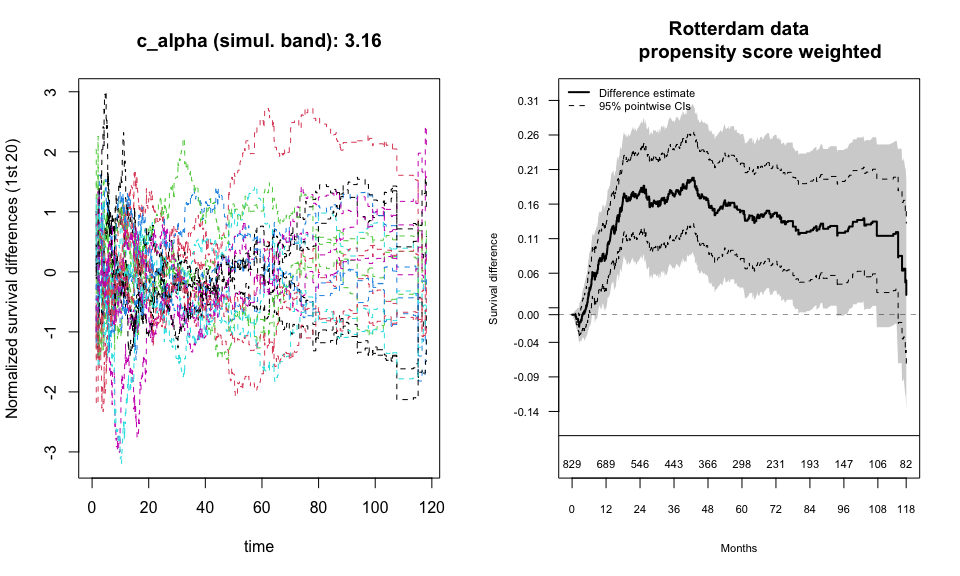

### 8. Rotterdam weighted and GBSG: survival-difference bands and cumulative RMST

vignettes/weightedsurv_examples.Rmd · chunk before: `unnamed-chunk-18 (figure 1)` · chunk after: `rotterdam-gbsg-bands (figure 1)` · image files differ

Before (ac76f82)

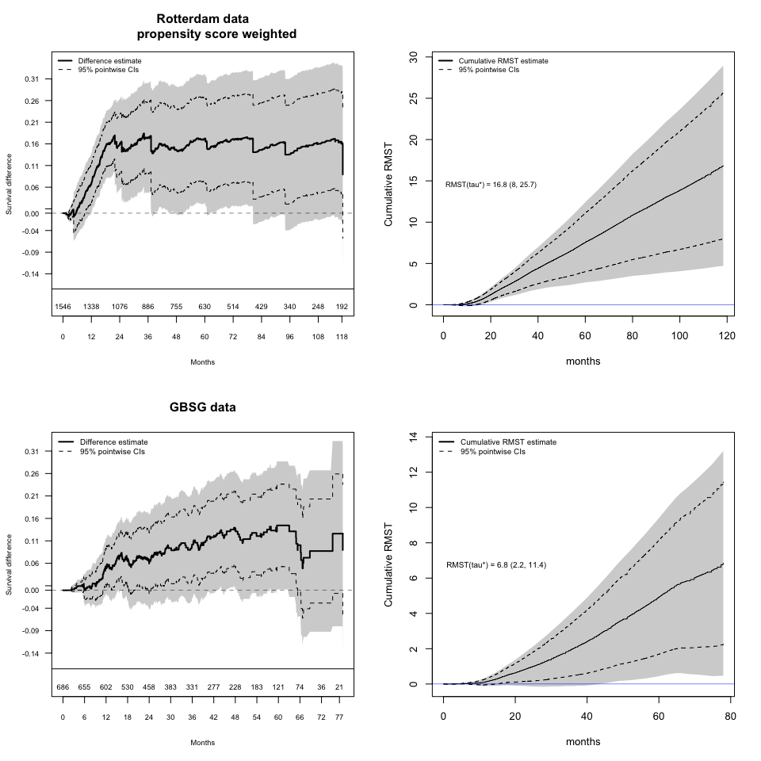

After (HEAD)

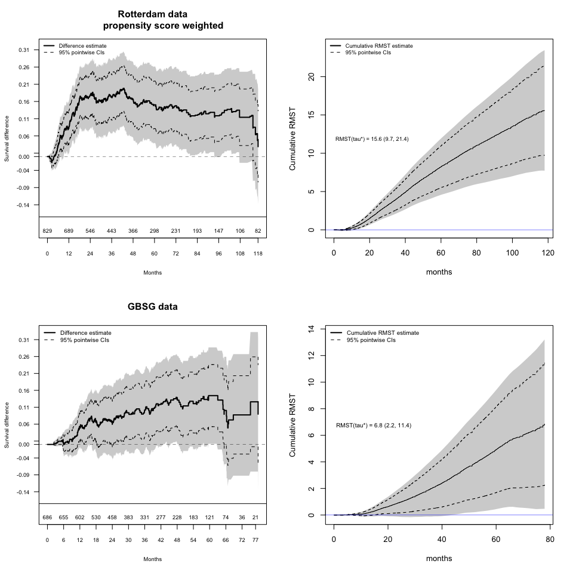

### 9. GBSG and cross-trial (CTC) K-M curves

vignettes/weightedsurv_examples.Rmd · chunk before: `unnamed-chunk-23 (figure 1)` · chunk after: `unnamed-chunk-23 (figure 1)` · image files byte-identical

Before (ac76f82)

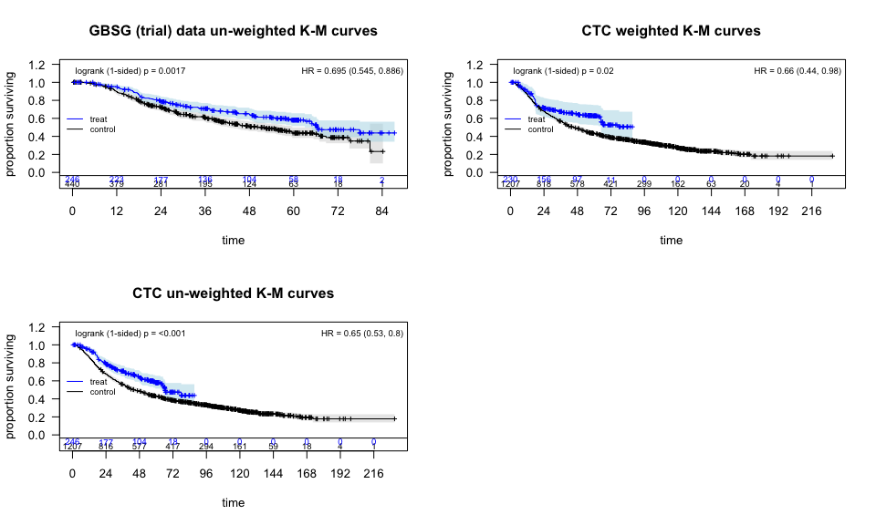

After (HEAD)

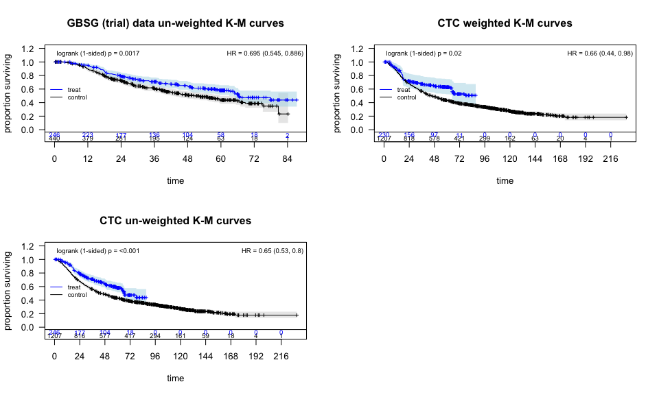

### 10. Cumulative weighted log-rank z (cross-trial)

vignettes/weightedsurv_examples.Rmd · chunk before: `unnamed-chunk-24 (figure 1)` · chunk after: `cumulative-logrank (figure 1)` · image files differ

Before (ac76f82)

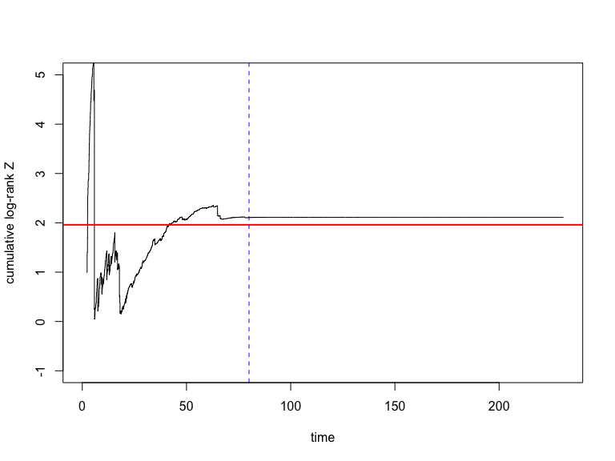

After (HEAD)

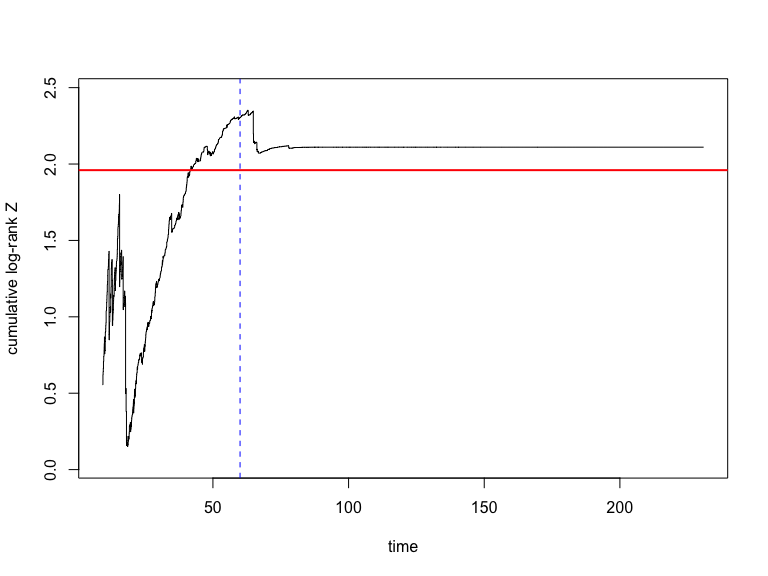

### 11. GBSG and cross-trial: survival-difference bands and cumulative RMST

vignettes/weightedsurv_examples.Rmd · chunk before: `unnamed-chunk-25 (figure 1)` · chunk after: `ctc-bands (figure 1)` · image files byte-identical

Before (ac76f82)

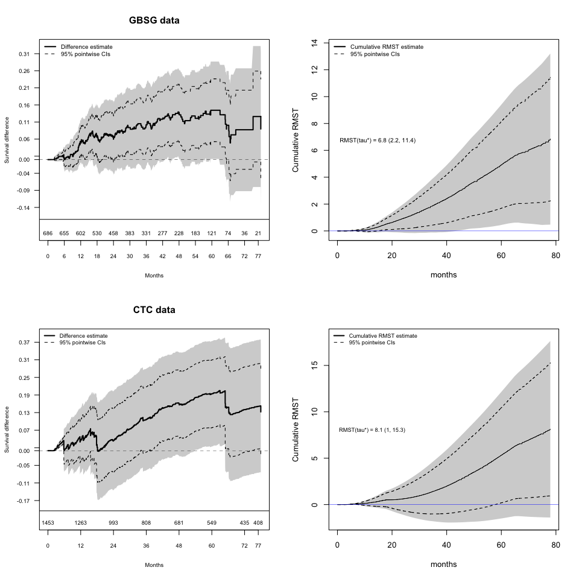

After (HEAD)

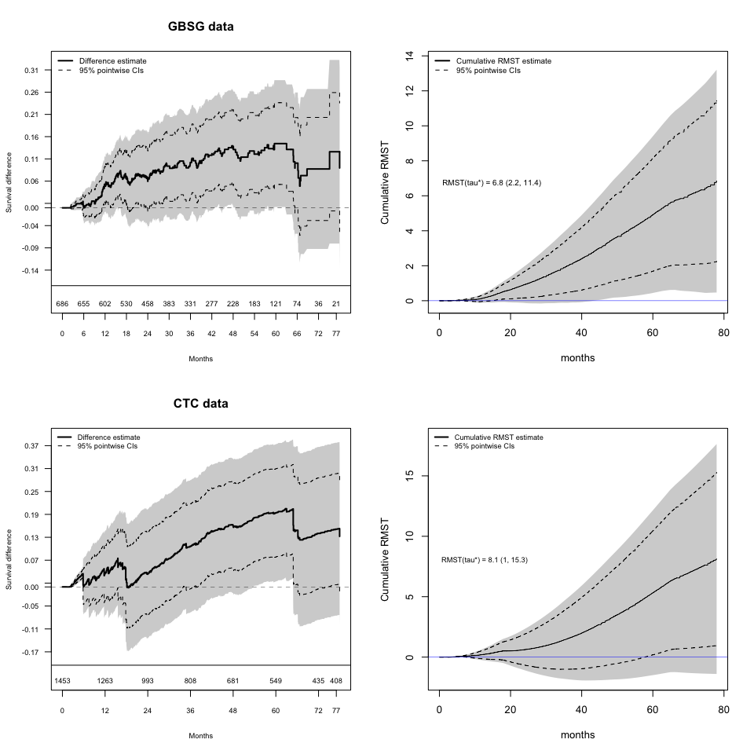

### 12. GBSG subgroups with ITT band

vignettes/weightedsurv_examples.Rmd · chunk before: `unnamed-chunk-26 (figure 1)` · chunk after: `unnamed-chunk-26 (figure 1)` · image files byte-identical

Before (ac76f82)

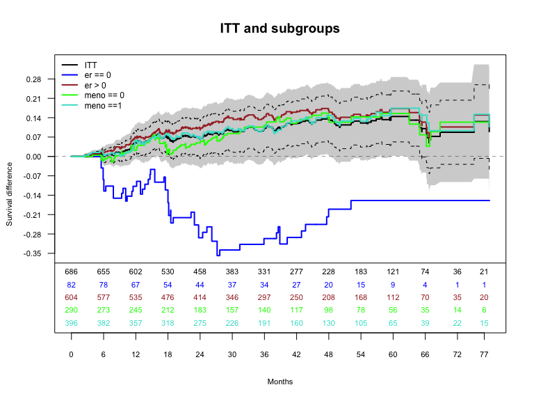

After (HEAD)

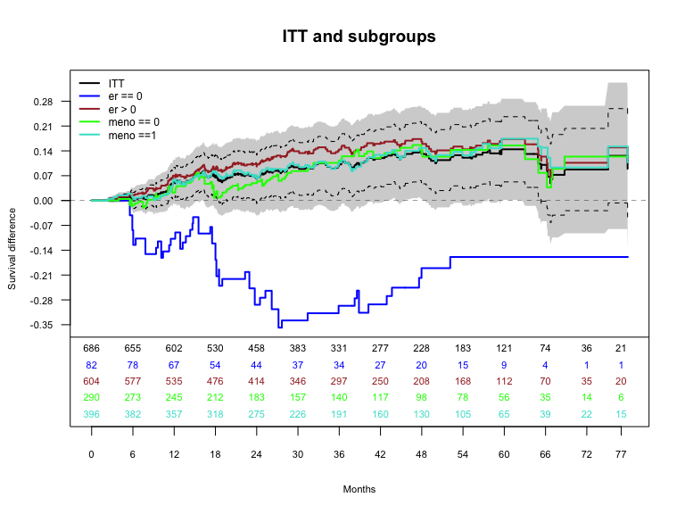

### 13. GBSG er > 0: resampled curves and band

vignettes/weightedsurv_examples.Rmd · chunk before: `unnamed-chunk-27 (figure 1)` · chunk after: `unnamed-chunk-27 (figure 1)` · image files byte-identical

Before (ac76f82)

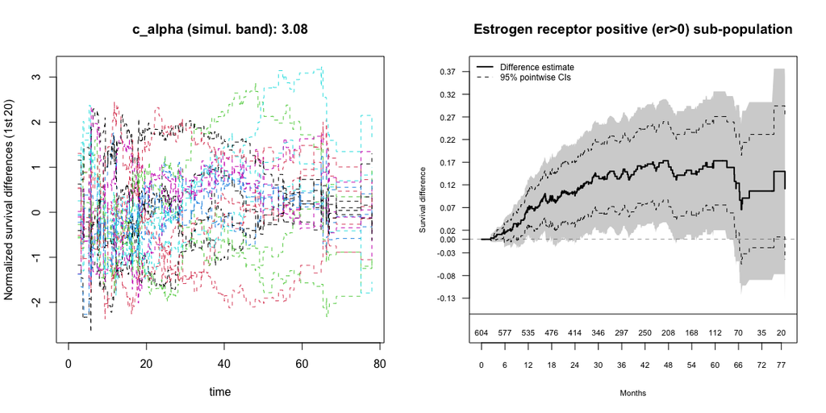

After (HEAD)

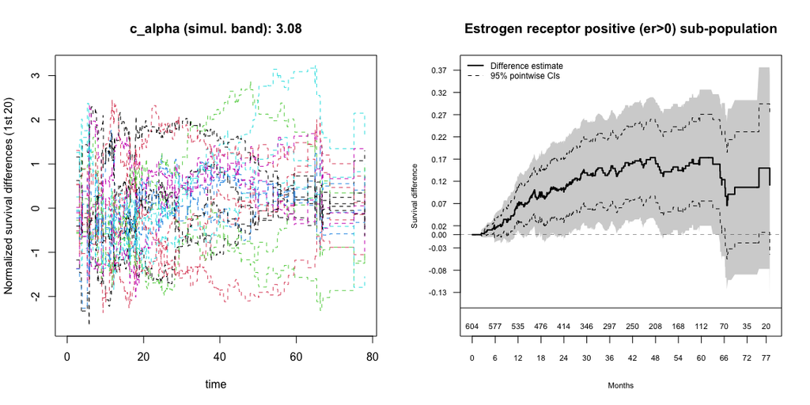

### 14. check.seKM: weighted K-M standard errors against survfit (draws = 0)

vignettes/weightedsurv_examples.Rmd · chunk before: `unnamed-chunk-29 (figure 1)` · chunk after: `unnamed-chunk-29 (figure 1)` · image files differ

Before (ac76f82)

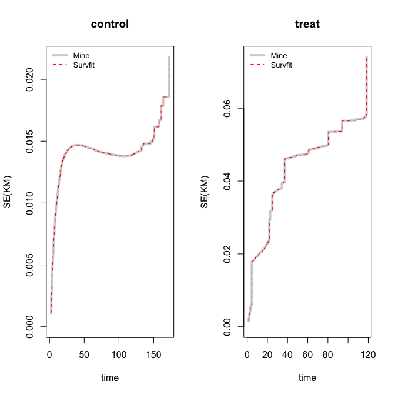

After (HEAD)

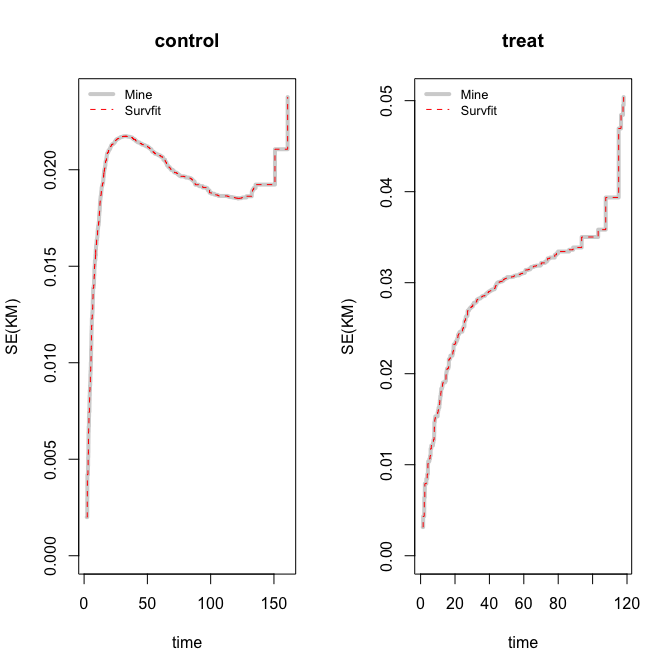

### 15. check.seKM: resampling standard errors (draws = 5000) against survfit

vignettes/weightedsurv_examples.Rmd · chunk before: `unnamed-chunk-30 (figure 1)` · chunk after: `unnamed-chunk-31 (figure 1)` · image files differ

Before (ac76f82)

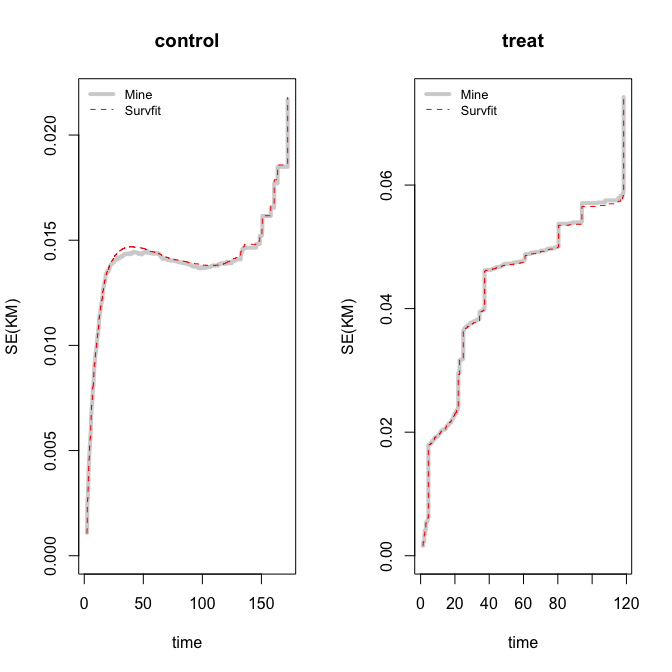

After (HEAD)

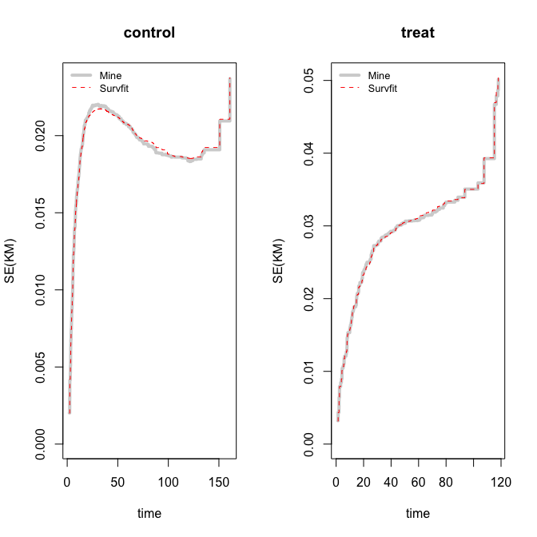

### 16. Rotterdam weighted K-M curves (for the adjustedCurves comparison)

vignettes/weightedsurv_examples.Rmd · chunk before: `unnamed-chunk-32 (figure 1)` · chunk after: `unnamed-chunk-33 (figure 1)` · image files differ

Before (ac76f82)

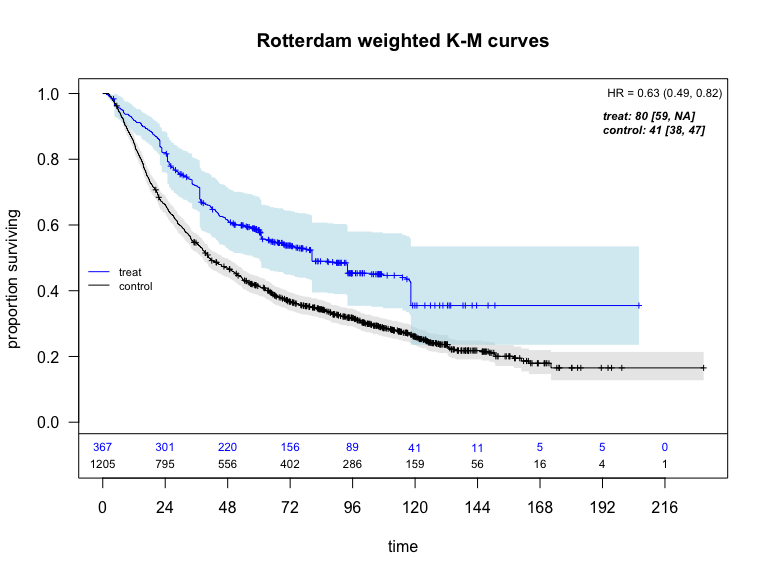

After (HEAD)

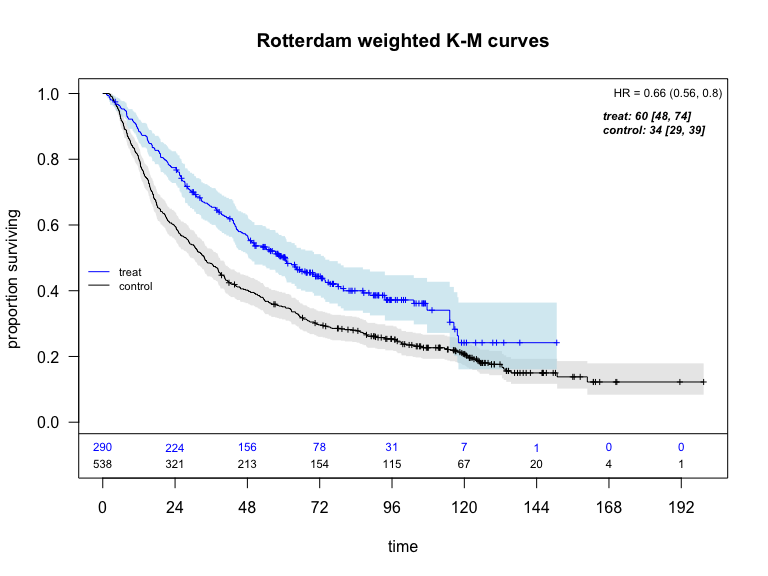

### 17. adjustedCurves iptw_km curves

vignettes/weightedsurv_examples.Rmd · chunk before: `unnamed-chunk-33 (figure 1)` · chunk after: `unnamed-chunk-34 (figure 1)` · image files differ

Before (ac76f82)

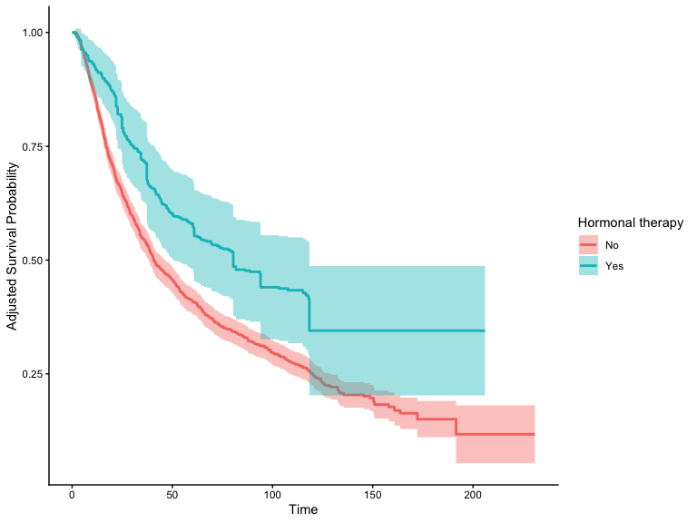

After (HEAD)

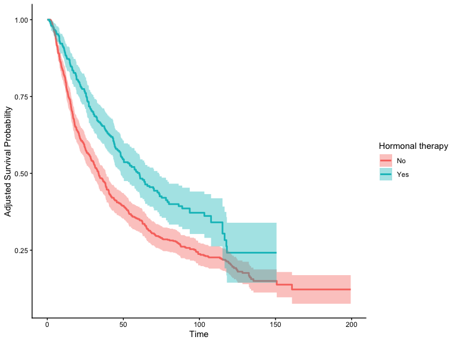